# descartes-test

```python
import pandas as pd
import numpy as np
import plotly.express as px
import re

from sklearn.model_selection import train_test_split
from sklearn.linear_model import LogisticRegression
from sklearn.metrics import classification_report, roc_auc_score, confusion_matrix, roc_curve
import lightgbm as lgb
import shap
pd.set_option("display.max_columns", 100)
```

### Get the data

```python
!kaggle competitions download -c auto-insurance-fall-2017
```

```
Downloading auto-insurance-fall-2017.zip to /Users/rdmgray/test
```

```python
df = pd.read_csv("./data/auto-insurance-fall-2017/train_auto.csv")
```

## EDA

### Target

From the instructions:

- the target is `TARGET_FLAG`

It seems like we're dealing with if a policy had a claim or not. The field `TARGET_AMT` appears to represent a severity. `CLAIM_FREQ` must be the prior claims.

```python
df["TARGET_FLAG"].value_counts(normalize=True)
```

```
0    0.736184
1    0.263816
Name: TARGET_FLAG, dtype: float64
```

There's an overall frequency of 26% in the training data.

### Features

Let's take an initial look at the features.

```python
df.columns
```

```
Index(['INDEX', 'TARGET_FLAG', 'TARGET_AMT', 'KIDSDRIV', 'AGE', 'HOMEKIDS',
       'YOJ', 'INCOME', 'PARENT1', 'HOME_VAL', 'MSTATUS', 'SEX', 'EDUCATION',
       'JOB', 'TRAVTIME', 'CAR_USE', 'BLUEBOOK', 'TIF', 'CAR_TYPE', 'RED_CAR',
       'OLDCLAIM', 'CLM_FREQ', 'REVOKED', 'MVR_PTS', 'CAR_AGE', 'URBANICITY'],
      dtype='object')
```

```python
df.head()
```

|  | INDEX | TARGET_FLAG | TARGET_AMT | KIDSDRIV | AGE | HOMEKIDS | YOJ | INCOME | PARENT1 | HOME_VAL | MSTATUS | SEX | EDUCATION | JOB | TRAVTIME | CAR_USE | BLUEBOOK | TIF | CAR_TYPE | RED_CAR | OLDCLAIM | CLM_FREQ | REVOKED | MVR_PTS | CAR_AGE | URBANICITY |
| --- | --- | --- | --- | --- | --- | --- | --- | --- | --- | --- | --- | --- | --- | --- | --- | --- | --- | --- | --- | --- | --- | --- | --- | --- | --- | --- |
| 0 | 1 | 0 | 0.0 | 0 | 60.0 | 0 | 11.0 | $67,349 | No | $0 | z_No | M | PhD | Professional | 14 | Private | $14,230 | 11 | Minivan | yes | $4,461 | 2 | No | 3 | 18.0 | Highly Urban/ Urban |
| 1 | 2 | 0 | 0.0 | 0 | 43.0 | 0 | 11.0 | $91,449 | No | $257,252 | z_No | M | z_High School | z_Blue Collar | 22 | Commercial | $14,940 | 1 | Minivan | yes | $0 | 0 | No | 0 | 1.0 | Highly Urban/ Urban |
| 2 | 4 | 0 | 0.0 | 0 | 35.0 | 1 | 10.0 | $16,039 | No | $124,191 | Yes | z_F | z_High School | Clerical | 5 | Private | $4,010 | 4 | z_SUV | no | $38,690 | 2 | No | 3 | 10.0 | Highly Urban/ Urban |
| 3 | 5 | 0 | 0.0 | 0 | 51.0 | 0 | 14.0 | NaN | No | $306,251 | Yes | M | <High School | z_Blue Collar | 32 | Private | $15,440 | 7 | Minivan | yes | $0 | 0 | No | 0 | 6.0 | Highly Urban/ Urban |
| 4 | 6 | 0 | 0.0 | 0 | 50.0 | 0 | NaN | $114,986 | No | $243,925 | Yes | z_F | PhD | Doctor | 36 | Private | $18,000 | 1 | z_SUV | no | $19,217 | 2 | Yes | 3 | 17.0 | Highly Urban/ Urban |

It looks like we have some data cleaning to do. We'll run through the columns and construct a function to clean the data.

- the fields `INCOME`, `HOME_VAL`, `BLUEBOOK` and `OLDCLAIM` should be converted to floats
- the fields `PARENT1`, `PARENT1`, `RED_CAR` and `REVOKED` should be converted to boolean
- we can also convert `SEX` and `URBANICITY` to boolean as there's only two levels
- a few fields have some rogue `z_` prefixes which we can remove for readability
- `CAR_AGE` has some negative values: it should be thresholded at 0 if it's a real age

```python
def _clean_data(df: pd.DataFrame) -> pd.DataFrame:

    for col in ["INCOME", "HOME_VAL", "BLUEBOOK", "OLDCLAIM"]:
        df[col] = df[col].apply(lambda x: re.sub(r"[$,]", "", x) if pd.notnull(x) else np.nan).astype(float)

    df["PARENT1"] = df["PARENT1"] == "Yes"
    df["MSTATUS"] = df["MSTATUS"] == "Yes"
    df["RED_CAR"] = df["RED_CAR"] == "yes"
    df["REVOKED"] = df["REVOKED"] == "Yes"
    df["SEX_M"] = df["SEX"] == "M"
    df["URBAN"] = df["URBANICITY"] == "Highly Urban/ Urban"
    df["CAR_USE_COMMERCIAL"] = df["CAR_USE"] == "Commercial"
    df = df.drop(columns=["SEX", "URBANICITY", "CAR_USE"])

    df["EDUCATION"] = df["EDUCATION"].replace({"z_High School": "High School"})
    df["JOB"] = df["JOB"].replace({"z_Blue Collar": "Blue Collar"})
    df["CAR_TYPE"] = df["CAR_TYPE"].replace({"z_SUV": "SUV"})

    for col in ["CAR_AGE", "AGE"]:
        df[col] = df[col].clip(lower=0)

    return df
```

```python
df = _clean_data(df)
```

Now it would be interesting to see the target distributions with respect to the features.

```python
categorical_features = [c for c in df if df[c].dtype == "O"]
boolean_features = [c for c in df if df[c].dtype == "bool"]
numerical_features = [c for c in df if c not in categorical_features and
                      c not in boolean_features and c not in ["INDEX", "TARGET_FLAG", "TARGET_AMT"]]
```

```python
def plot_target_by_feature(df, feature):
    if (feature in categorical_features + boolean_features) or len(df[feature].unique()) < 100 :
        fig = px.bar(df.groupby([feature])["TARGET_FLAG"].mean().reset_index(),
           x=feature,
           y="TARGET_FLAG",
           )
    else:
        df = df.copy()
        df[f"{feature}_banded"] = pd.cut(df[feature], bins=20)
        df[f"{feature}_banded"] = df[f"{feature}_banded"].apply(lambda x: f"{x.left:.1f}-{x.right:.1f}")
        fig = px.bar(df.groupby([f"{feature}_banded"])["TARGET_FLAG"].mean().reset_index(),
           x=f"{feature}_banded",
           y="TARGET_FLAG",
           )
    fig.show()
```

I am using this function to inspect all features, but I won't print them all here for readability, only some interesting ones.

```python
plot_target_by_feature(df, categorical_features[0])
```

[interactive chart not shown]

```python
plot_target_by_feature(df, boolean_features[2])
```

[interactive chart not shown]

There doesn't seem to be any relationship in the `RED_CAR` feature, which is what we would expect I suppose if it is really if the car is painted red.

```python
plot_target_by_feature(df, boolean_features[4])
```

[interactive chart not shown]

There also doesn't seem to be any relationship in the `SEX` feature, which is actually surprising as male drivers are known to perform much worse, especially younger drivers.

```python
px.line(df.groupby(["AGE", "SEX_M"])["TARGET_FLAG"].mean().reset_index(),
      x="AGE",
      y="TARGET_FLAG",
      color="SEX_M")
```

[interactive chart not shown]

Difficult to make the case that we do see that trend.

```python
plot_target_by_feature(df, boolean_features[5])
```

[interactive chart not shown]

Urbanicity is a very strong feature - almost no claims in the countryside it seems.

```python
plot_target_by_feature(df, numerical_features[1])
```

[interactive chart not shown]

Age is quite a strong feature - it follows the non-linear trend we would expect.

```python
plot_target_by_feature(df, numerical_features[4])
```

[interactive chart not shown]

```python
px.histogram(df, x="HOME_VAL", color="TARGET_FLAG")
```

[interactive chart not shown]

A few of the numerical features have similar attributes to income:

- A noticeable trend
- Some high outlying values (long tail)
- A lot of zeros. It's not clear what a 0 income or house price means so maybe we should treat these values differently.

```python
plot_target_by_feature(df, numerical_features[4])
```

[interactive chart not shown]

## Preparation for modelling

Now we can prepare the data for modelling. First we need to deal with missing values.

In the absence of any other information about the cause of the missing values, it should be ok to fill with the median/most common value.

```python
def _fill_missing_values(df: pd.DataFrame) -> pd.DataFrame:
    for col in df.columns:
        if df[col].isna().sum() > 0:
            if col not in categorical_features:
                df[col] = df[col].fillna(df[col].median())
            else:
                df[col] = df[col].fillna(df[col].mode())
    return df
```

```python
df = _fill_missing_values(df)
```

We also need to handle categorical features.

```python
categorical_features
```

```
['EDUCATION', 'JOB', 'CAR_TYPE']
```

You could make a case to label-encode education as it has an ordering but we'll just one-hot encode everything as we can't be sure of the meaning really.

```python
def _one_hot_encode_categorical(df: pd.DataFrame) -> pd.DataFrame:
    encoded_categorical = pd.get_dummies(df[categorical_features])
    return pd.concat([df.drop(columns=categorical_features), encoded_categorical], axis=1)
```

```python
df = _one_hot_encode_categorical(df)
```

```python
df.head()
```

|  | INDEX | TARGET_FLAG | TARGET_AMT | KIDSDRIV | AGE | HOMEKIDS | YOJ | INCOME | PARENT1 | HOME_VAL | MSTATUS | TRAVTIME | BLUEBOOK | TIF | RED_CAR | OLDCLAIM | CLM_FREQ | REVOKED | MVR_PTS | CAR_AGE | SEX_M | URBAN | CAR_USE_COMMERCIAL | EDUCATION_<High School | EDUCATION_Bachelors | EDUCATION_High School | EDUCATION_Masters | EDUCATION_PhD | JOB_Blue Collar | … |
| --- | --- | --- | --- | --- | --- | --- | --- | --- | --- | --- | --- | --- | --- | --- | --- | --- | --- | --- | --- | --- | --- | --- | --- | --- | --- | --- | --- | --- | --- | --- |
| 0 | 1 | 0 | 0.0 | 0 | 60.0 | 0 | 11.0 | 67349.0 | False | 0.0 | False | 14 | 14230.0 | 11 | True | 4461.0 | 2 | False | 3 | 18.0 | True | True | False | 0 | 0 | 0 | 0 | 1 | 0 | … |
| 1 | 2 | 0 | 0.0 | 0 | 43.0 | 0 | 11.0 | 91449.0 | False | 257252.0 | False | 22 | 14940.0 | 1 | True | 0.0 | 0 | False | 0 | 1.0 | True | True | True | 0 | 0 | 1 | 0 | 0 | 1 | … |
| 2 | 4 | 0 | 0.0 | 0 | 35.0 | 1 | 10.0 | 16039.0 | False | 124191.0 | True | 5 | 4010.0 | 4 | False | 38690.0 | 2 | False | 3 | 10.0 | False | True | False | 0 | 0 | 1 | 0 | 0 | 0 | … |
| 3 | 5 | 0 | 0.0 | 0 | 51.0 | 0 | 14.0 | 54028.0 | False | 306251.0 | True | 32 | 15440.0 | 7 | True | 0.0 | 0 | False | 0 | 6.0 | True | True | False | 1 | 0 | 0 | 0 | 0 | 1 | … |
| 4 | 6 | 0 | 0.0 | 0 | 50.0 | 0 | 11.0 | 114986.0 | False | 243925.0 | True | 36 | 18000.0 | 1 | False | 19217.0 | 2 | True | 3 | 17.0 | False | True | False | 0 | 0 | 0 | 0 | 1 | 0 | … |

## Modelling

It's a classification problem so we can start with a logistic regression.

In terms of metrics we can look at precision/recall and confusion matrix, but also ROC AUC score.

```python
X_train, X_test, y_train, y_test = train_test_split(df.drop(columns=["INDEX", "TARGET_FLAG", "TARGET_AMT"]),
                                    df["TARGET_FLAG"],
                                    test_size=0.2,
                                    random_state=1)
```

```python
lr = LogisticRegression(class_weight="balanced")
lr.fit(X_train, y_train)
```

```
LogisticRegression(class_weight='balanced')
```

```python
print(classification_report(y_test, lr.predict(X_test)))
```

```
              precision    recall  f1-score   support

           0       0.80      0.74      0.77      1195
           1       0.41      0.49      0.45       438

    accuracy                           0.67      1633
   macro avg       0.60      0.62      0.61      1633
weighted avg       0.69      0.67      0.68      1633
```

```python
confusion_matrix(y_test, lr.predict(X_test))
```

```
array([[884, 311],
       [222, 216]])
```

```python
roc_auc_score(y_test, lr.predict_proba(X_test)[:,1])
```

```
0.6811295160581571
```

Let's try lightgbm instead. We would expect better performance as there are clearly non-linear trends in the data. We can use early stopping as a hyperparameter tuning short-cut.

I'm slightly upweighting the positive class so we get a sensible class balance in the predictions so we can use confusion matrix etc to assess the performance.

```python
from lightgbm import LGBMClassifier
```

```python
def train_lgbm_early_stopping(X_train: pd.DataFrame, y_train: pd.Series) -> LGBMClassifier:
    train_x, valid_x, train_y, valid_y,  = train_test_split(X_train, y_train, test_size=0.2, random_state=2)

    train = lgb.Dataset(train_x, train_y)
    valid = lgb.Dataset(valid_x, valid_y)

    params = {"objective":"binary",
              "metric": "binary_logloss",
              "num_iterations": 20000,
              "num_leaves": 32,
              "class_weight": {1:1.5,0:1}
              # "extra_trees": True
              }
    evals_result = {}
    lgb_model = LGBMClassifier(**params)
    lgb_model.fit(train_x, train_y,
                  eval_set=(valid_x, valid_y),
                    early_stopping_rounds=50
                 )
    return lgb_model
```

```python
lgb_model = train_lgbm_early_stopping(X_train, y_train)
```

[output not shown]

[output cut: 54 more lines]

```
[95]	valid_0's binary_logloss: 0.454775
[96]	valid_0's binary_logloss: 0.454713
[97]	valid_0's binary_logloss: 0.455018
[98]	valid_0's binary_logloss: 0.45545
[99]	valid_0's binary_logloss: 0.455219
[100]	valid_0's binary_logloss: 0.454996
[101]	valid_0's binary_logloss: 0.455156
[102]	valid_0's binary_logloss: 0.455016
[103]	valid_0's binary_logloss: 0.454641
[104]	valid_0's binary_logloss: 0.454667
[105]	valid_0's binary_logloss: 0.455454
[106]	valid_0's binary_logloss: 0.455389
[107]	valid_0's binary_logloss: 0.455387
[108]	valid_0's binary_logloss: 0.455644
[109]	valid_0's binary_logloss: 0.455984
```

```python
print(classification_report(y_test, lgb_model.predict(X_test)))
```

```
              precision    recall  f1-score   support

           0       0.86      0.86      0.86      1195
           1       0.62      0.62      0.62       438

    accuracy                           0.80      1633
   macro avg       0.74      0.74      0.74      1633
weighted avg       0.80      0.80      0.80      1633
```

```python
confusion_matrix(y_test, lgb_model.predict(X_test))
```

```
array([[1028,  167],
       [ 165,  273]])
```

```python
roc_auc_score(y_test,lgb_model.predict_proba(X_test)[:,1])
```

```
0.8430255440285819
```

```python
pd.Series(lgb_model.predict(X_test)).value_counts(normalize=True)
```

```
0    0.730557
1    0.269443
dtype: float64
```

```python
y_test.value_counts(normalize=True)
```

```
0    0.731782
1    0.268218
Name: TARGET_FLAG, dtype: float64
```

This model is quite good - we wouldn't normally expect to be able to predict exactly when claims will occur, just model the frequency.

## Analyse model

Feature importances

```python
px.bar(pd.Series(index=X_train.columns,
                 data=lgb_model.feature_importances_,
                name="Importance").sort_values(ascending=False))
```

[interactive chart not shown]

Shap values

```python
shap_values = shap.TreeExplainer(lgb_model).shap_values(X_train)
```

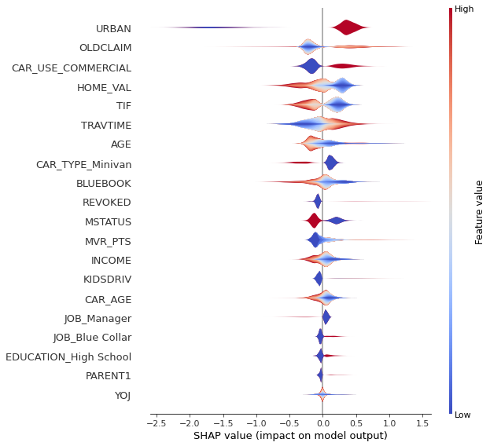

```python
shap.summary_plot(shap_values[1], X_train, plot_type="layered_violin", color='coolwarm')
```

Overall the feature importances and trends from the shap values make a lot of sense and align with what we saw in the target distribution plots.

## Iteration

We can make some further changes to the data based on what we saw in the EDA and our initial model. Specifically:

```python
def _further_processing(df: pd.DataFrame) -> pd.DataFrame:
    df = df.drop(columns=["RED_CAR", "SEX_M"])
    for col in ["HOME_VAL"]:
        df[f"{col}_0"]= (df[col] == 0).astype(int)
        df.loc[df[col] == 0, col] = np.nan
        df[col] = df[col].fillna(df[col].median())

    return df
```

```python
df = _further_processing(df)
```

```python
X_train, X_test, y_train, y_test = train_test_split(df.drop(columns=["INDEX", "TARGET_FLAG", "TARGET_AMT"]),
                                    df["TARGET_FLAG"],
                                    test_size=0.2,
                                    random_state=1)

lgb_model2 = train_lgbm_early_stopping(X_train, y_train)
```

[output not shown]

[output cut: 41 more lines]

```
[82]	valid_0's binary_logloss: 0.451304
[83]	valid_0's binary_logloss: 0.451158
[84]	valid_0's binary_logloss: 0.451824
[85]	valid_0's binary_logloss: 0.45217
[86]	valid_0's binary_logloss: 0.451885
[87]	valid_0's binary_logloss: 0.451534
[88]	valid_0's binary_logloss: 0.451173
[89]	valid_0's binary_logloss: 0.45147
[90]	valid_0's binary_logloss: 0.451876
[91]	valid_0's binary_logloss: 0.452344
[92]	valid_0's binary_logloss: 0.452441
[93]	valid_0's binary_logloss: 0.452324
[94]	valid_0's binary_logloss: 0.452469
[95]	valid_0's binary_logloss: 0.451865
[96]	valid_0's binary_logloss: 0.451454
```

```python
roc_auc_score(y_test,lgb_model2.predict_proba(X_test)[:,1])
```

```
0.841118816988594
```

## Predict test data

We just need to apply the same transformations to the test data to make our predictions. We should probably abstract them into a class but that's a bit much for this exercise so we will just make it work.

```python
def _fill_missing_values_test(df_test: pd.DataFrame,
                             df: pd.DataFrame) -> pd.DataFrame:
    for col in df_test.columns:
        if df_test[col].isna().sum() > 0:
            if col not in categorical_features:
                df_test[col] = df_test[col].fillna(df[col].median())
            else:
                df_test[col] = df_test[col].fillna(df[col].mode())
    return df_test
```

```python
df_test = pd.read_csv("./data/auto-insurance-fall-2017/test_auto.csv")
df = pd.read_csv("./data/auto-insurance-fall-2017/train_auto.csv")
```

```python
df_test = _clean_data(df_test)
df = _clean_data(df)
df_test = _fill_missing_values_test(df_test, df)
df_test = _one_hot_encode_categorical(df_test)
df_test = _further_processing(df_test)
```

```python
test_predictions = lgb_model2.predict_proba(df_test[X_train.columns])[:,1]
```

Get the predictions in the format requested on the kaggle page. It says:

For each ID in the test set, you must predict a probability for the TARGET variable. The file should contain a header and have the following format: index, p_target 2,0 5,0 6,0 etc.

It's a little confusing because it says to predict probabilities but the example doesn't look like probabilities...we'll just predict probabilities.

```python
test_predictions = pd.Series(index=df_test["INDEX"], data=test_predictions, name="p_target").reset_index()
test_predictions = test_predictions.round(4)
test_predictions.columns = [c.lower() for c in test_predictions]
```

```python
test_predictions
```

|  | index | p_target |
| --- | --- | --- |
| 0 | 3 | 0.1834 |
| 1 | 9 | 0.5106 |
| 2 | 10 | 0.0664 |
| 3 | 18 | 0.1239 |
| 4 | 21 | 0.2098 |
| ... | ... | ... |
| 2136 | 10279 | 0.5358 |
| 2137 | 10281 | 0.0783 |
| 2138 | 10285 | 0.0546 |
| 2139 | 10294 | 0.1699 |
| 2140 | 10300 | 0.1496 |

2141 rows × 2 columns

```python
test_predictions.to_csv("test_predictions.csv", index=False)
```